# Where are people moving in the UK

## Top performing areas

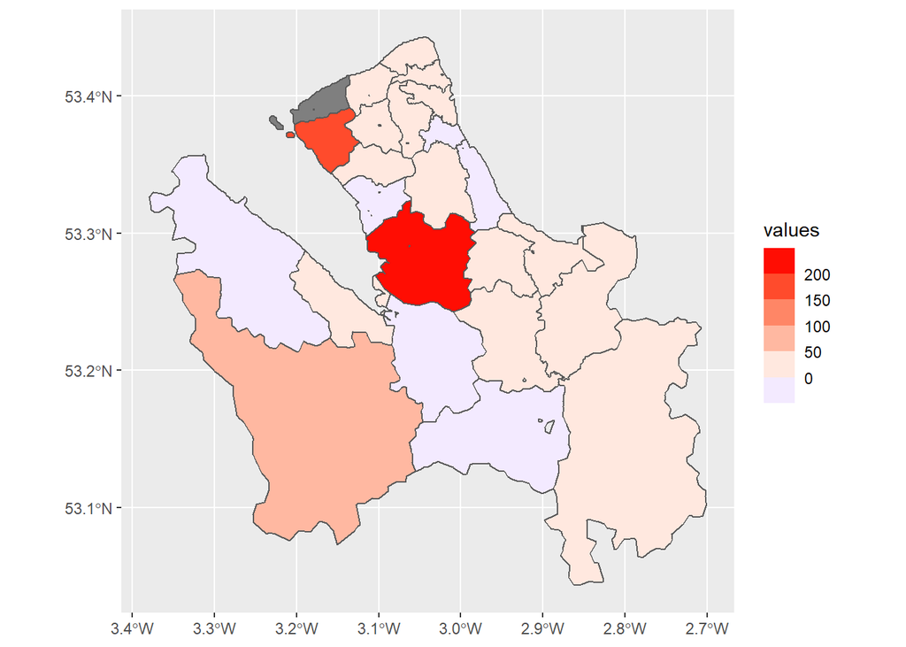

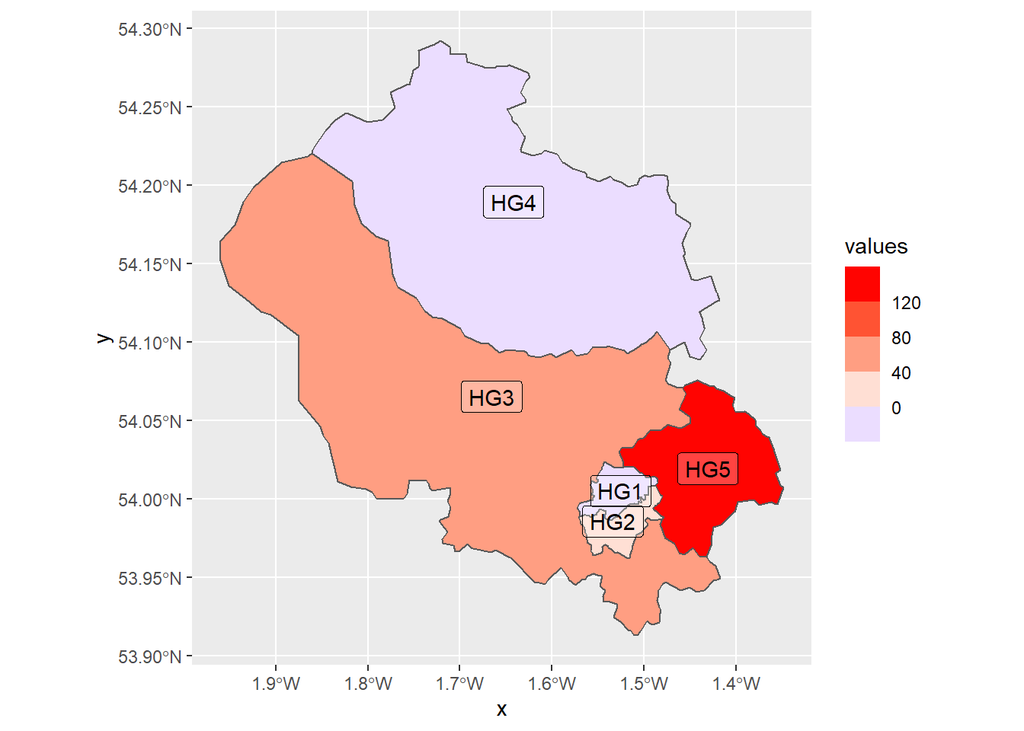

## London

Finally turning attention to London which has apparently born the brunt of movement during the pandemic. Looking at the data presented above it appears that people are leaving in droves because it is the biggest city. However, breaking the figures down by residential type reveals a slightly different picture.

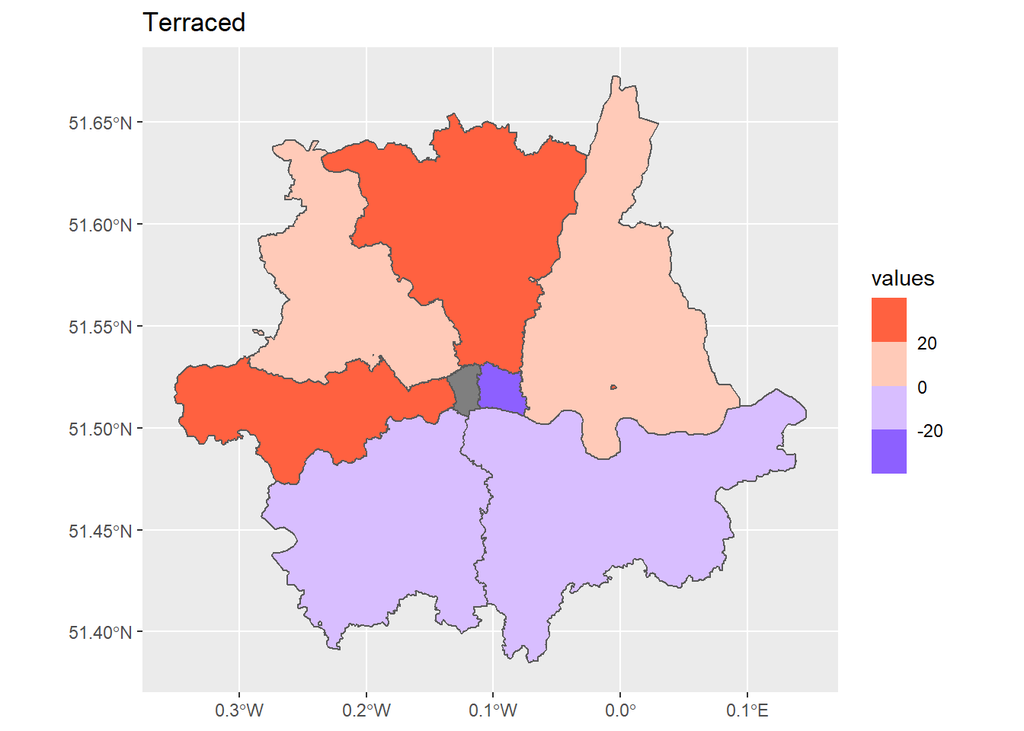

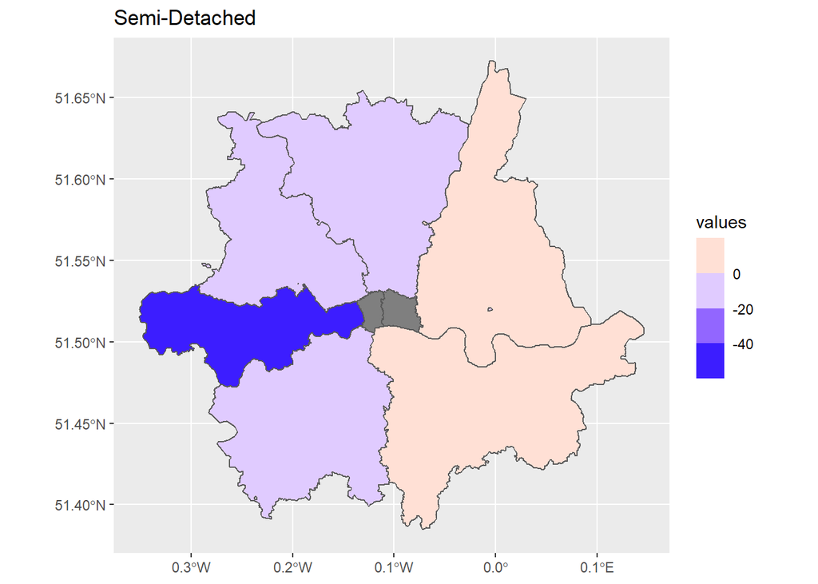

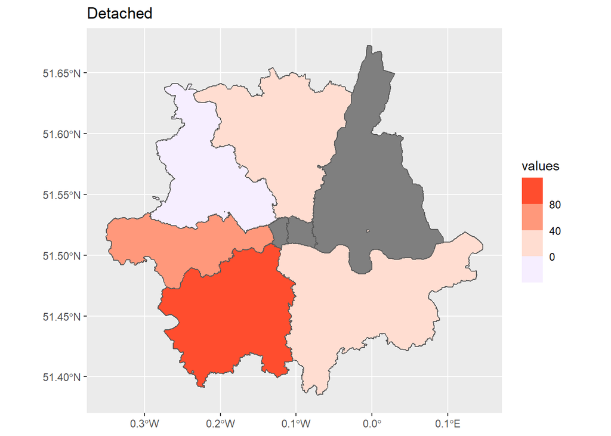

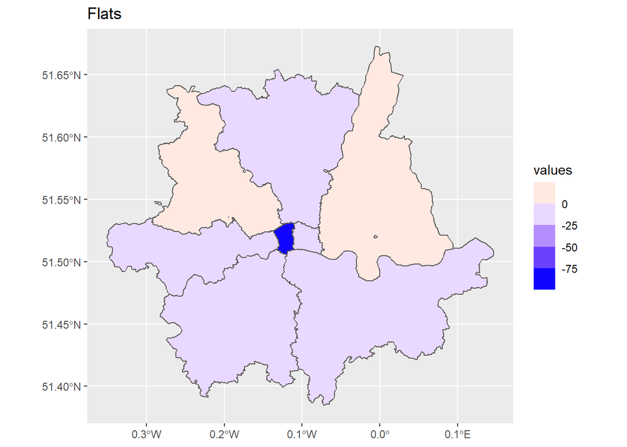

Those areas where the avaerage price is falling by the greatest amount Eastern Central (EC) and Western Central (WC) are those areas where Flats make up almost all the housing stock.

[figure not shown]

[figure not shown]